# Caractéristiques individuelles

## Sexe

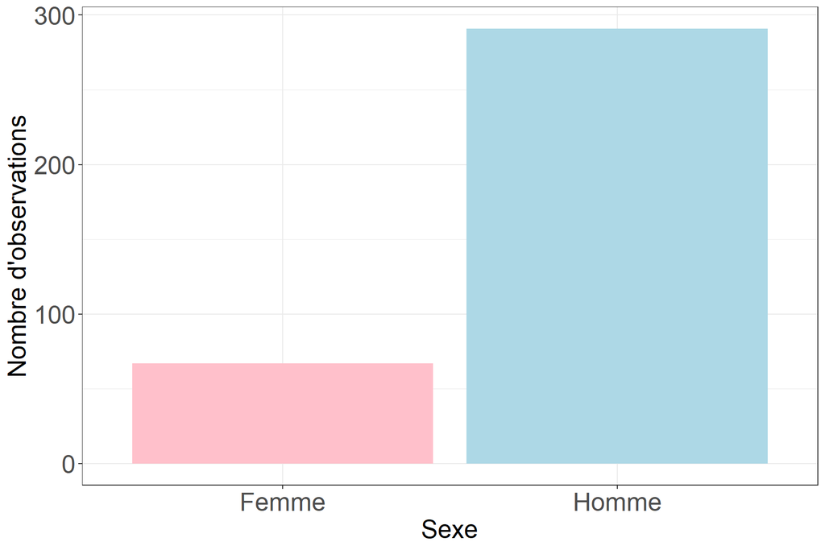

Représentation de la répartition homme/femme

Nous observons qu’une majorité d’hommes a répondu à ce questionnaire. Environ 4/5 des volontaires sont de sexe masculin.

## Age

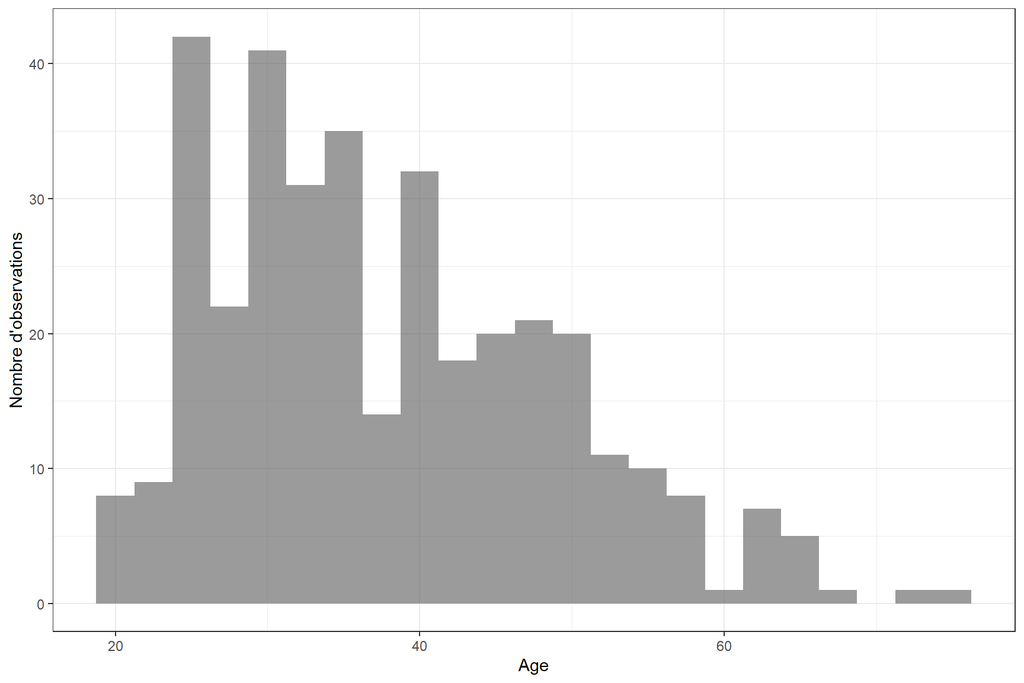

Représentation de la répartition par age

Nous observons qu’une majorité des répondants à ce questionnaire font partie de la tranche d’âge 25 à 40 ans. Nous remarquons également que peu de personnes de moins de 25 ans et de plus de 50 ans ont répondu. En ce qui concerne les personnes âgés de 40 à 50 ans, la répartition est plutôt homogène.

## Poids

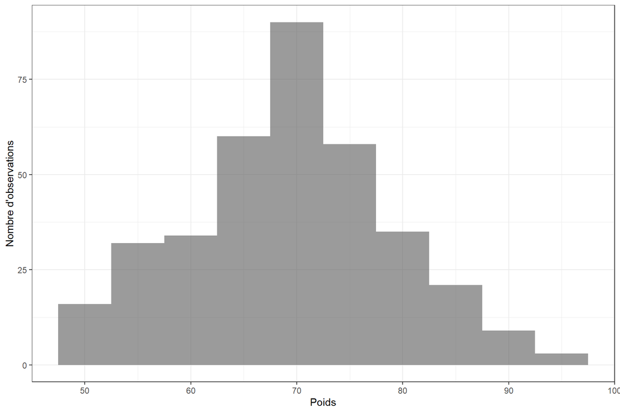

Représentation de la répartition par poids

Nous observons une majorité de participants pesant entre 60 et 80 kg. Nous remarquons également peu d’extrêmes.

## Poids maximal

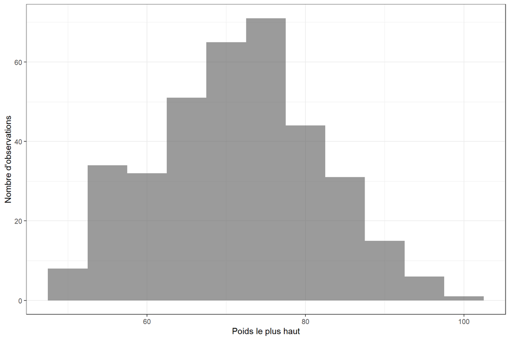

Représentation de la répartition par poids le plus haut

Le poids maximal est lui aussi majoritairement compris entre 60 et 80 kg. Là aussi, nous observons très peu d’extrêmes.

## Poids minimal

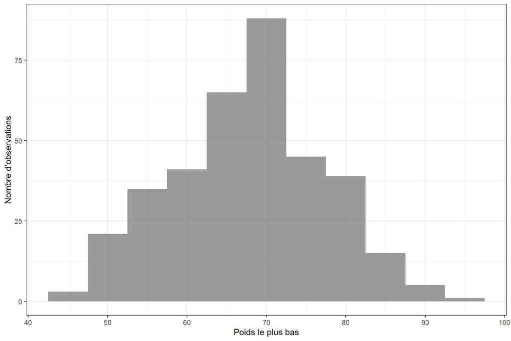

Représentation de la répartition par poids le plus bas

Le poids minimal est, quant à lui, majoritairement compris entre 60 et 75 kg. Là encore, nous observons très peu d’extrêmes.

## Temps consacré à la profession

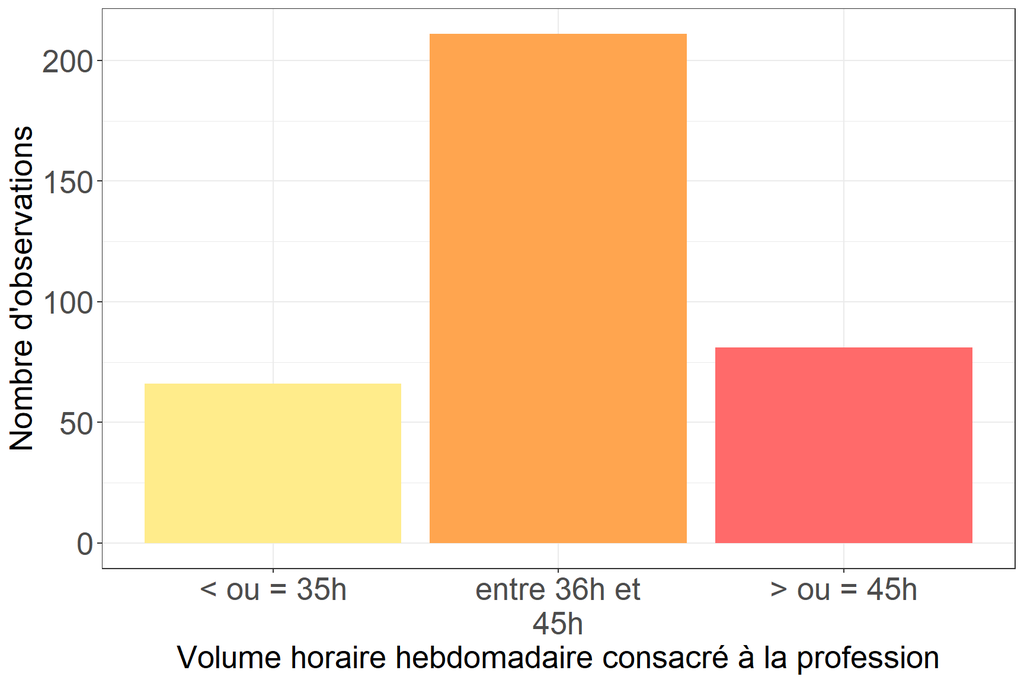

Quel volume hebdomadaire est consacré à votre profession ?

Nous observons que la majorité des traileurs ayant répondu à ce questionnaire consacrent entre 36 et 45h à leur profession.

# Caractéristiques sportives

## Début de la pratique du trail

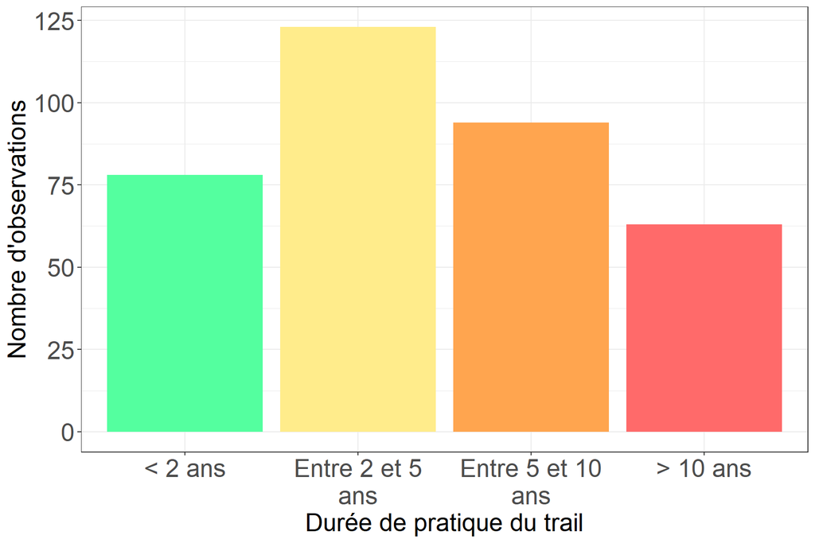

Depuis combien de temps pratiquez-vous le trail ?

L’expérience de la pratique du trail des répondants est plutôt bien répartie, avec une majorité de personnes le pratiquant depuis 2 à 5 ans.

## Autres pratiques sportives

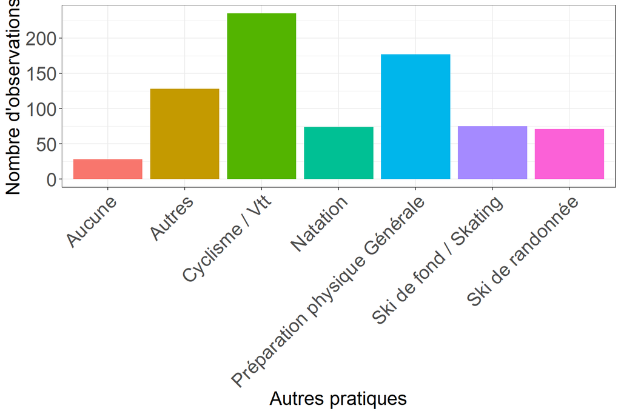

Quelle.s autre.s discipline.s pratiquez-vous en plus de la course à pied / trail ?

On remarque que la grande majorité des participants est multi-disciplinaire. Beaucoup pratiquent également le cyclisme et la préparation physique générale.

## Temps consacré aux autres pratiques sportives

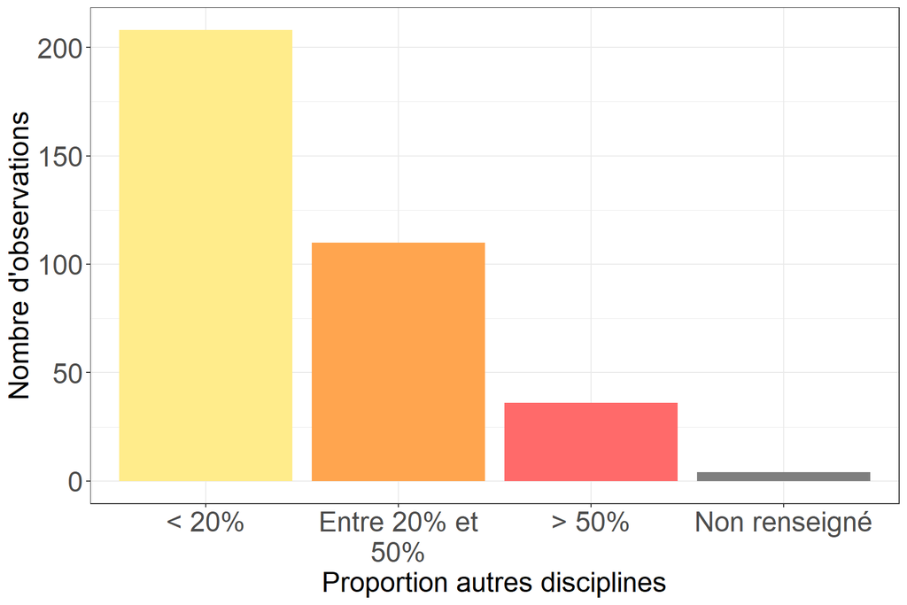

Quelle est la proportion de ces autres disciplines dans votre volume total d’entraînement ?

On note que peu de traileurs allouent une partie importante de leur temps aux autres disciplines, avec une majorité d’entre eux leur consacrant moins de 20% du temps.

## Coach de trail

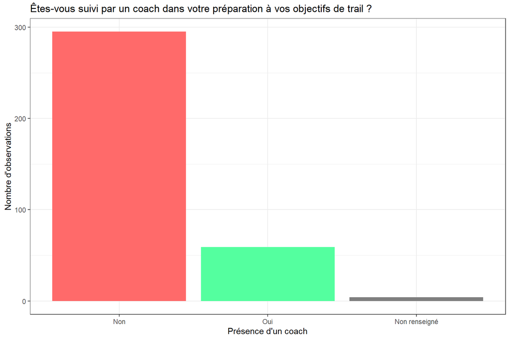

On remarque que la plupart des coureurs ont répondus à cette question. Une grande majorité d’entre eux ne sont pas suivis par un coach dans leur préparation.

## Cardiofréquencemètre à l’entraînement

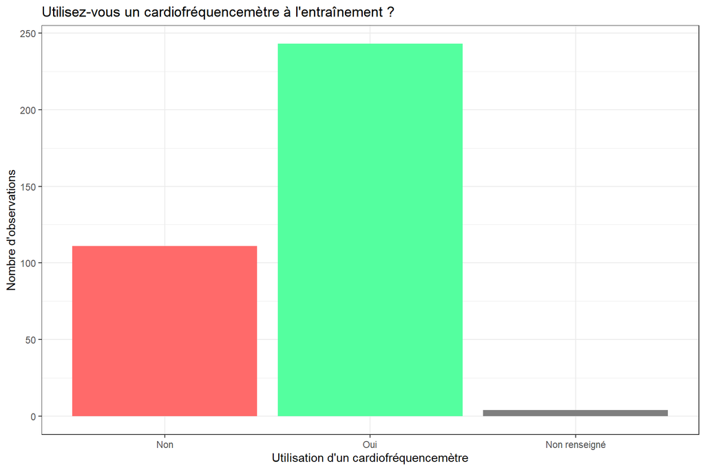

Pour cette question, presque tous les coureurs ont répondus. Beaucoup d’entre eux utilisent un cardiofréquencemètre à l’entraînement, environ 1/3 n’en utilisent pas.

## Cardiofréquencemètre en compétition

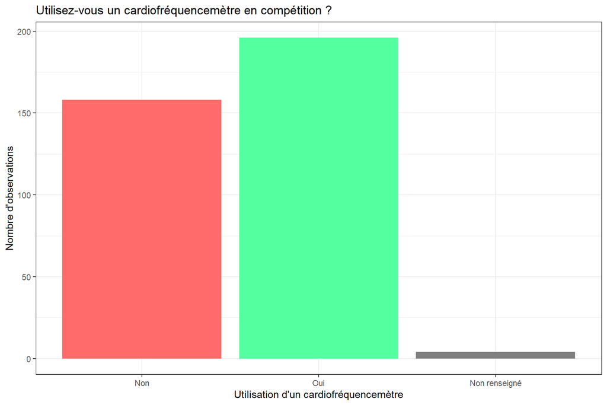

Ici encore, il y a très peu de données manquantes. Presque autant de coureurs utilisent et n’utilisent pas de cardiofréquencemètre en compétition. La proportion de coureurs qui n’en utilise pas est d’environ 3/7e.

## Enregistrement des performances sur une plateforme connectée

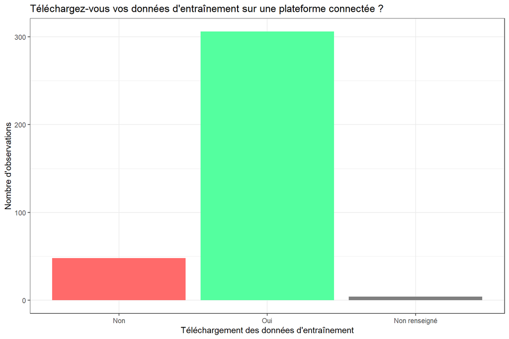

Il y a très peu de données manquantes pour cette question. Beaucoup de coureurs utilisent une plateforme pour télécharger leurs données d’entraînement, environ 6/7e.

## Connaissance de la côte ITRA

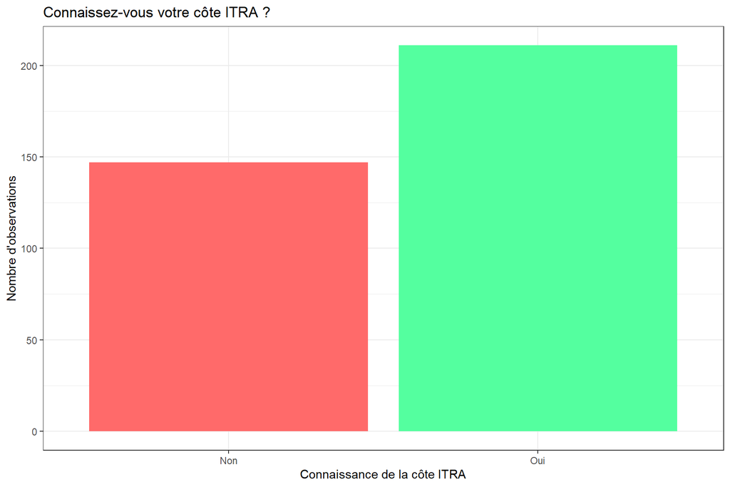

Encore ici, il y a peu de données manquantes, 3/7 des répondants ne connaissent pas leur côte ITRA.

## Côte ITRA

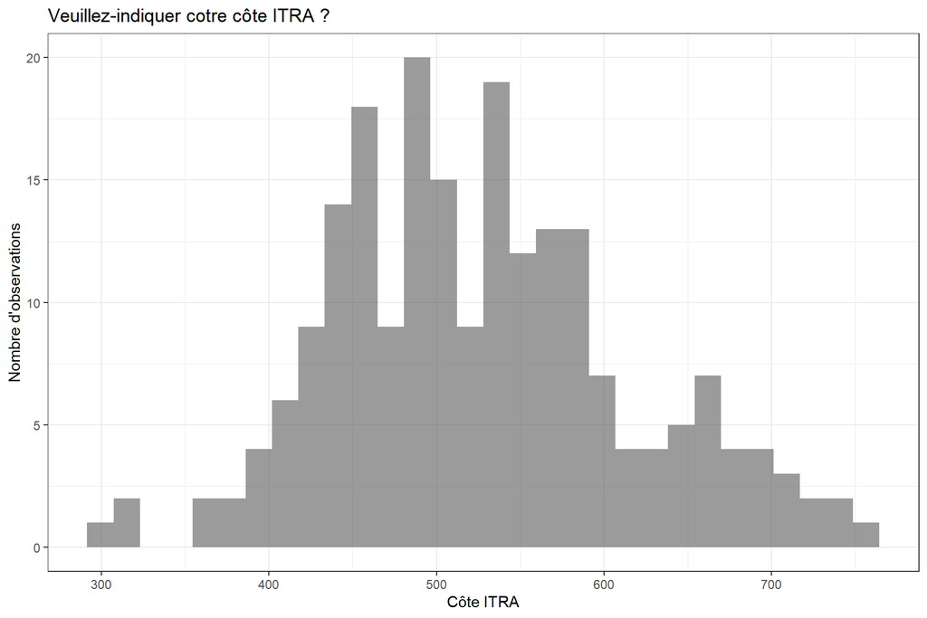

On remarque que les côtes ITRA des participants sont majoritairement entre 400 et 600.

## Nombre d’heures de pratiques de trail pendant la préparation d’une course

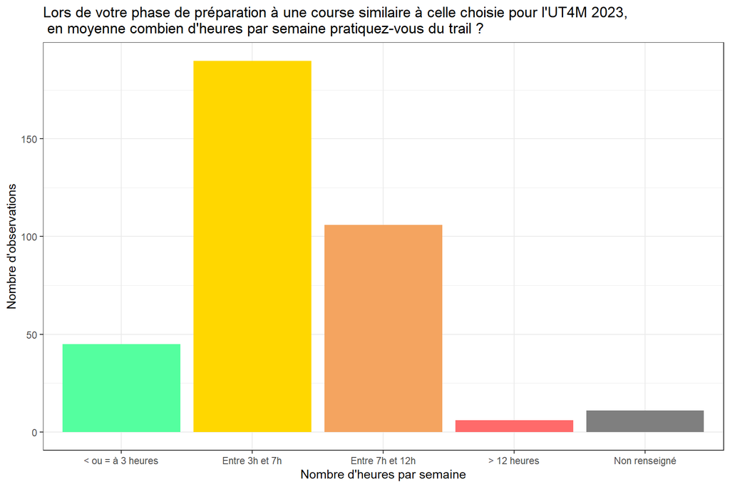

On retrouve peu de données manquantes pour cette question. La majorité des coureurs s’entraine entre 3 et 7h par semaine et une autre partie importante entre 7 et 12h. Il y a très peu de coureurs qui s’entraînent plus de 12h.

## Dénivelé effectué pendant la préparation d’une course

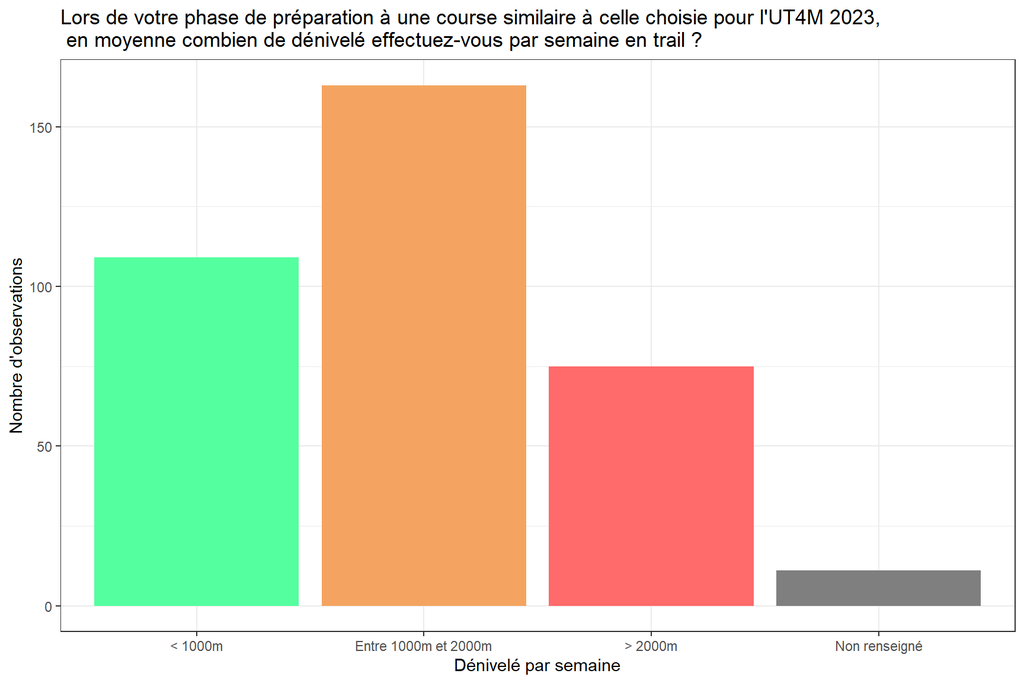

Il y a peu de données manquantes pour cette question. Le dénivelé effectué par les coureurs par semaine est réparti de façon relativement homogène avec tout de même une majorité qui effectue entre 1000 et 2000m de dénivelé par semaine.

## Nombre de kilomètre parcourus pendant la préparation d’une course

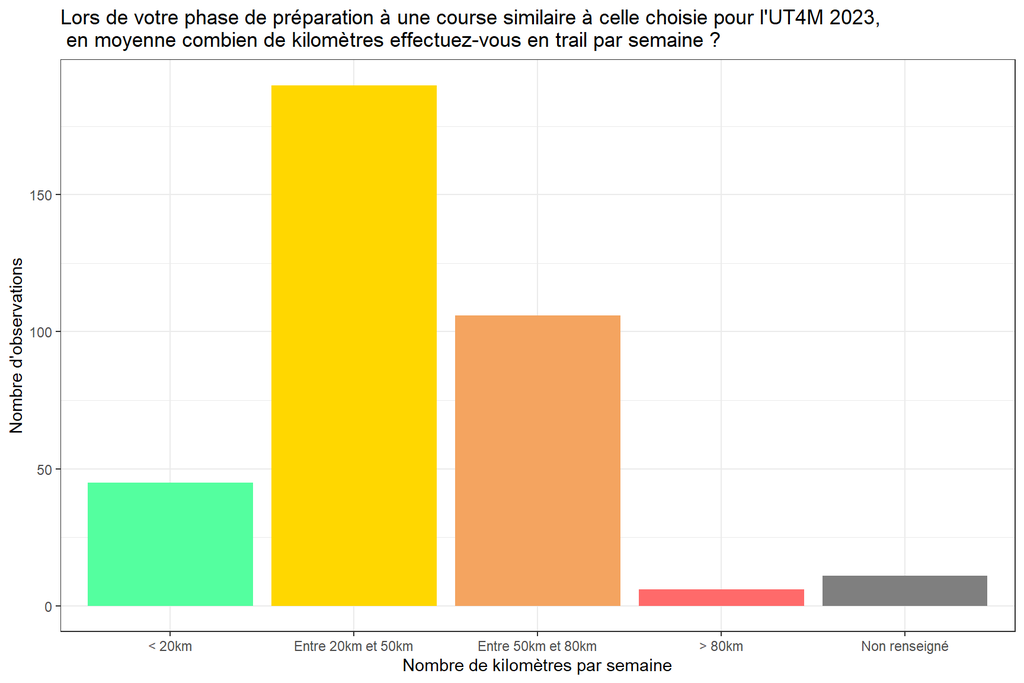

On retrouve peu de données manquantes pour cette question. La majorité des coureurs parcourt entre 20 et 50km par semaine et une autre partie importante entre 50 et 80km. Il y a très peu de coureurs qui effectuent plus de 80km.

## Nombre d’heures de pratiques sportives pendant la préparation d’une course

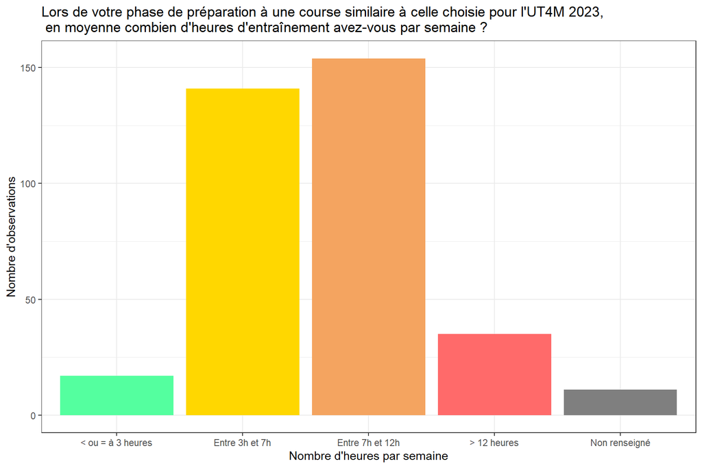

Les coureurs effectuent principalement entre 3 et 12h de sport par semaine pour s’entraîner. Très peu d’entre eux font moins de 3h ou plus de 12h de sport.

## Participation à des trails lors des deux dernières saisons

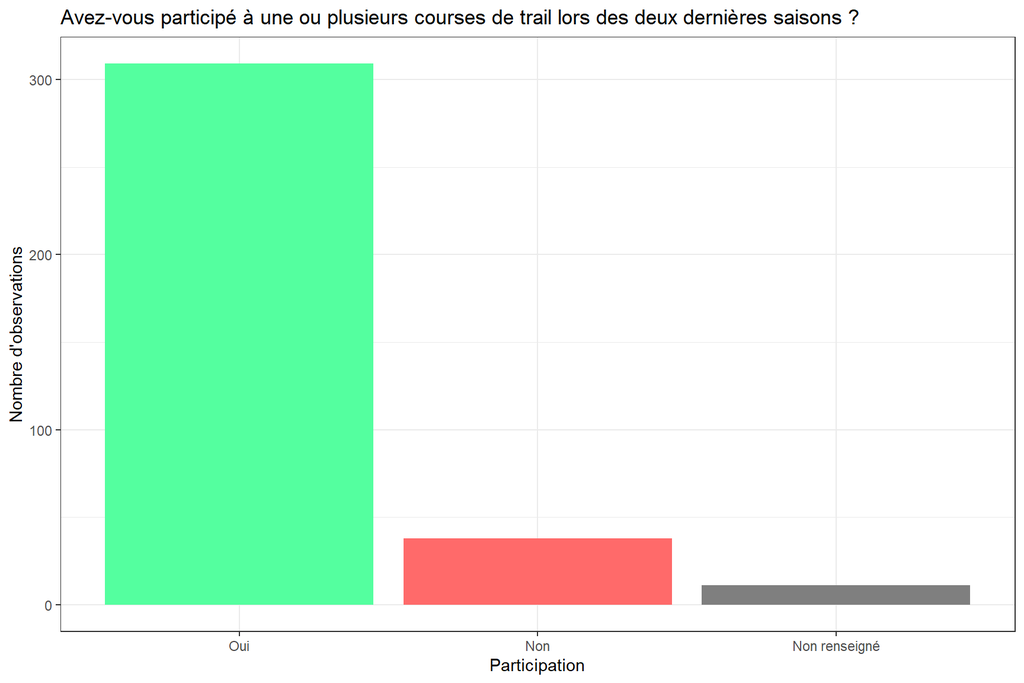

La majorité a participé à une ou plusieurs courses de trail lors des deux dernières saisons.

## Distance des trails réalisés lors des deux dernières saisons

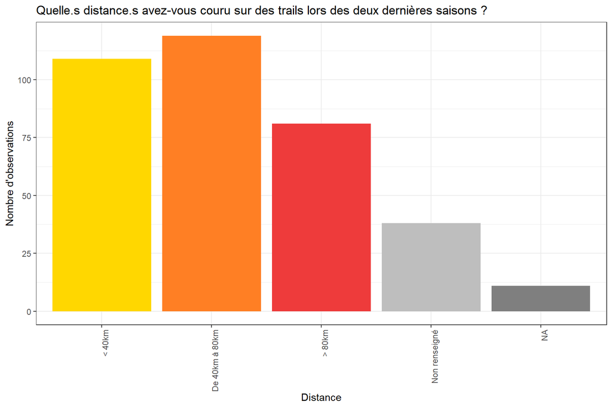

Les coureurs ont participé à des trails lors des deux dernières saisons sur globalement tous types de distances. On retrouve 50 personnes qui n’ont pas répondu à la question.

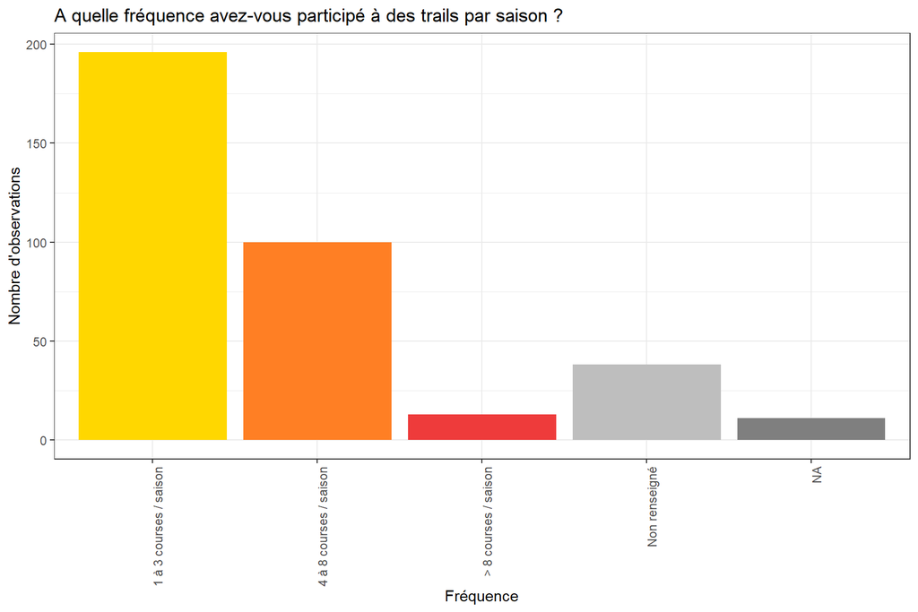

La majorité participe à moins de 3 courses par saison. Peu de personnes courent plus de 8 trails par saison.

## Courses de l’UT4M

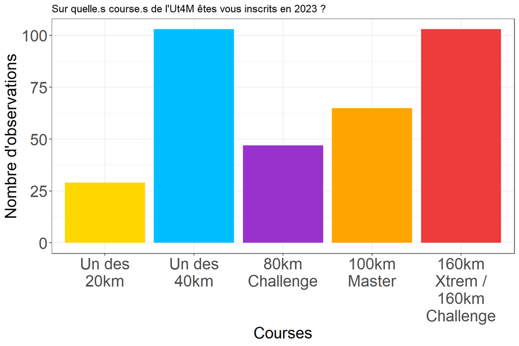

Les participants sont majoritairement inscrits sur un des 40km et un des 160km. On retrouve tout de même pas mal d’inscriptions sur le 100km.

# Régime et hydratation

## Régime alimentaire

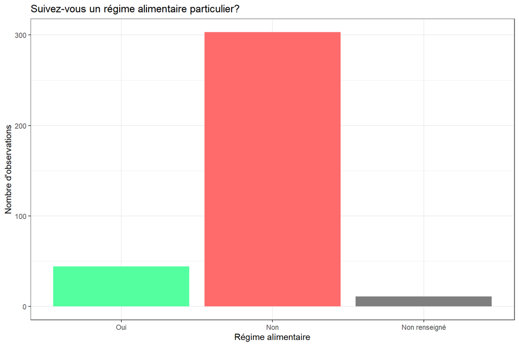

La plupart des coureurs ne suivent pas de régime alimentaire spécifique.

## Type de régime alimentaire suivi

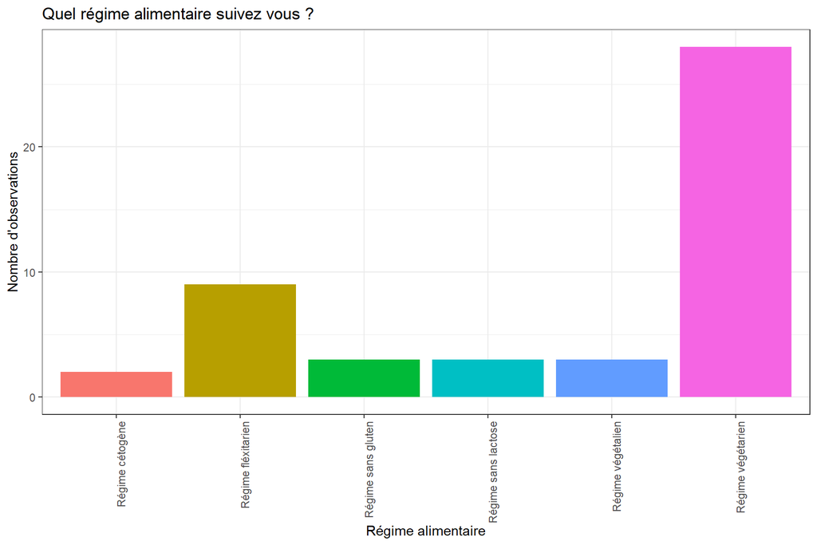

## Boisson pendant l’entrainement

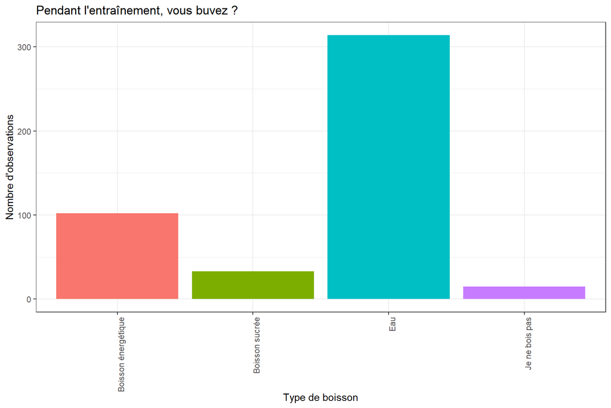

Plus de 300 personnes boivent de l’eau à l’entrainement et environ 100 prennent des boissons énergétiques. Peu de personnes ne boivent pas.

## Volume de boisson bu à l’entrainement

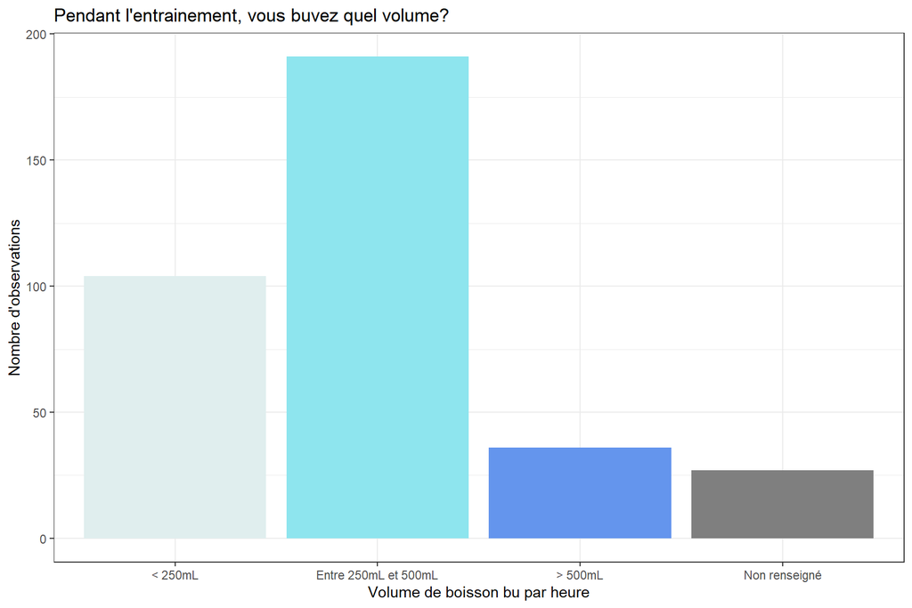

La majorité boit entre 250 et 500ml de boisson par heure à l’entrainement.

## Boisson pendant la compétition

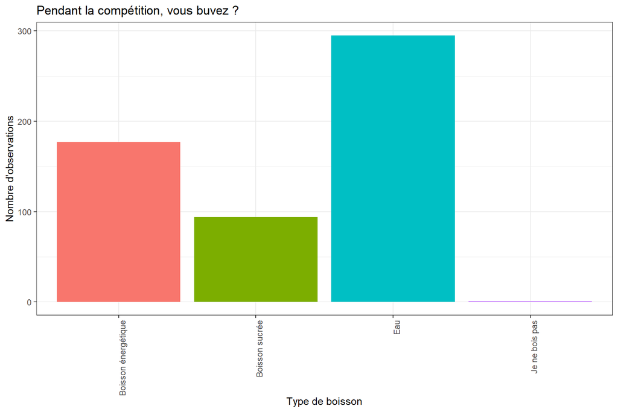

Principalement, les gens boivent de l’eau et de la boisson énergétique. Quasiment aucune personne ne bois pas.

## Volume de boisson bu en compétition

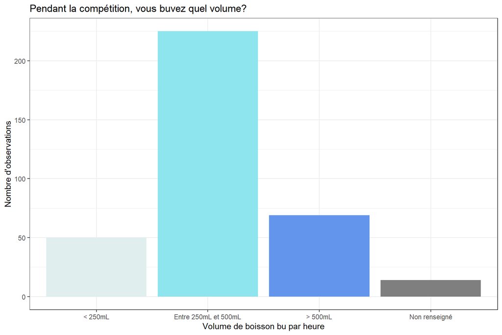

La coureurs prennent entre 250 et 500ml de boisson par heure pendant la compétition.

## Alimentation pendant l’entraînement

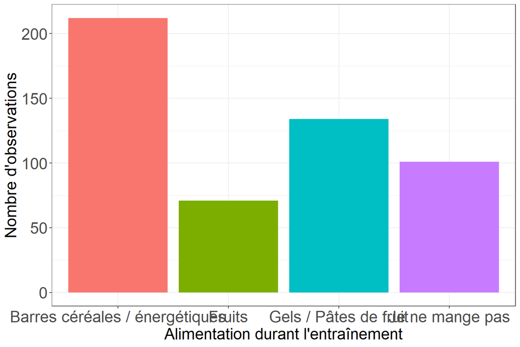

Pendant l’entraînement, vous mangez ?

Nous observons que la majorité des traileurs consomment des barres de céréales ou énergétiques durant leur entraînement.

## Fréquence d’alimentation pendant l’entraînement

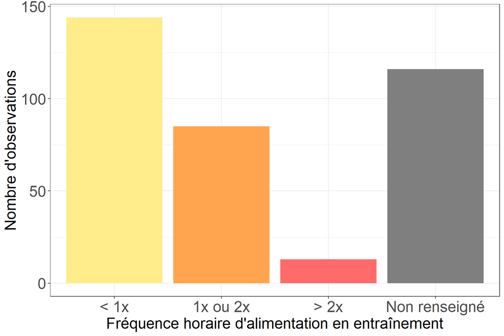

Pendant l’entraînement, a quelle fréquence vous mangez ?

Durant leur entraînement, il apparaît que les traileurs mangent relativement peu souvent, moins d’une fois par heure. Cependant, beaucoup de personnes n’ont pas répondu à cette question.